# What is wrong with Brain??

## Number of matches across different pairs of tissues

- Create a \( 53 \times 53 \) table such that the entry \( (i,j) \) corresponds to the number of persons contributing both tissues i and j.
- Then construct the heatmap of the table to see which tissues have higher number of matched individuals between them.

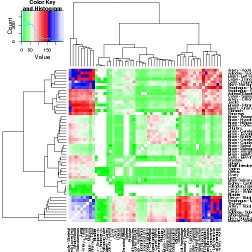

## Correlation Heatmaps without shrinkage

- Create a \( 53 \times 53 \times 5000 \) matrix for the top \( 5000 \) genes as per their mean gene expression. So, for each gene, we have a \( 53 \times 53 \) matrix of the correlation between the tissues. If there are no matched individuals between two tissues, the entry in the matrix corresponding to these two values is put to NA for each gene.

### gene 1

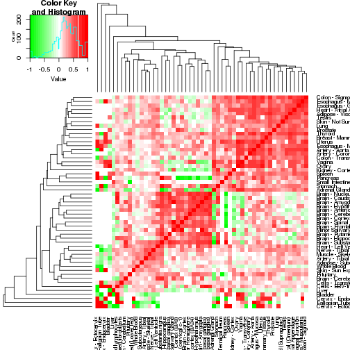

```r
col=c(rgb(seq(0,1,length=15),1,seq(0,1,length=15)),rgb(1,seq(1,0,length=15),seq(1,0,length=15)))
library(gplots)
heatmap.2(diag(1,53)+cor_tissue1_tissue2_genes[,,1],scale="none",trace="none",labRow=U,
          labCol=U,breaks=c(seq(-1,0,0.07),seq(0,0.5,0.05),seq(0.6,1,0.1)),col=col,
          distfun=function(x) dist(x,method="euclidean"),
          hclustfun=function(x) hclust(x,method="average"));
```

### gene 10

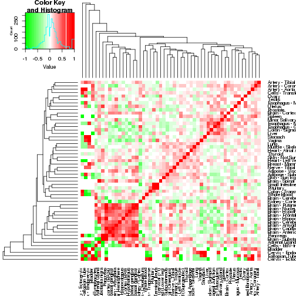

```r
heatmap.2(diag(1,53)+cor_tissue1_tissue2_genes[,,10],scale="none",trace="none",labRow=U,
          labCol=U,breaks=c(seq(-1,0,0.07),seq(0,0.5,0.05),seq(0.6,1,0.1)),col=col,
          distfun=function(x) dist(x,method="euclidean"),
          hclustfun=function(x) hclust(x,method="average"));
```

### gene 500

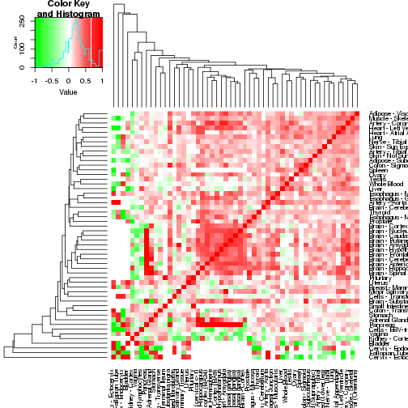

```r
heatmap.2(diag(1,53)+cor_tissue1_tissue2_genes[,,500],scale="none",trace="none",labRow=U,
          labCol=U,breaks=c(seq(-1,0,0.07),seq(0,0.5,0.05),seq(0.6,1,0.1)),col=col,
          distfun=function(x) dist(x,method="euclidean"),
          hclustfun=function(x) hclust(x,method="average"));
```

### gene 5000

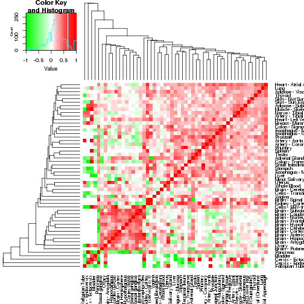

```r
heatmap.2(diag(1,53)+cor_tissue1_tissue2_genes[,,5000],scale="none",trace="none",labRow=U,
          labCol=U,breaks=c(seq(-1,0,0.07),seq(0,0.5,0.05),seq(0.6,1,0.1)),col=col,
          distfun=function(x) dist(x,method="euclidean"),
          hclustfun=function(x) hclust(x,method="average"));
```

### gene 2000

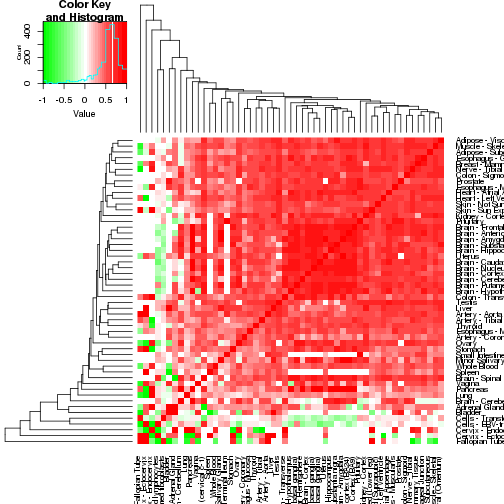

```r
heatmap.2(diag(1,53)+cor_tissue1_tissue2_genes[,,2000],scale="none",trace="none",labRow=U,
          labCol=U,breaks=c(seq(-1,0,0.07),seq(0,0.5,0.05),seq(0.6,1,0.1)),col=col,
          distfun=function(x) dist(x,method="euclidean"),
          hclustfun=function(x) hclust(x,method="average"));
```

### gene 3500

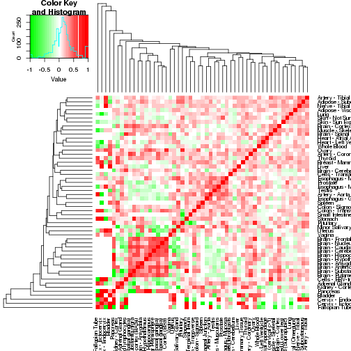

```r
heatmap.2(diag(1,53)+cor_tissue1_tissue2_genes[,,3500],scale="none",trace="none",labRow=U,
          labCol=U,breaks=c(seq(-1,0,0.07),seq(0,0.5,0.05),seq(0.6,1,0.1)),col=col,
          distfun=function(x) dist(x,method="euclidean"),
          hclustfun=function(x) hclust(x,method="average"));
```

## Ash Transformed Correlation Heatmaps

- We take the correlation table for the \( 5000 \) genes in the previous step and for each tissue-pair, we first observe the number of matched individuals between them.
- If there are less than 10 individuals matched, then we put the correlation between the two tissues to NA. This leaves us with a set of tissues for which there are more than 10 individuals.
- Now for each of these tissue-pairs, we apply Fisher transformation on the correlation coefficients for the $5000% genes and then apply adaptive shrinkage using the **ash** package (**https://github.com/stephens999/ashr**) on these 5000 transformed correlations, and then reverse transform them back to the original scale of the correlation coefficients. The idea here is that the method will shrink the correlations towards \( 0 \) thereby making the positive correlations more distinct.
- The cor-ash transformed heatmaps are presented as follows, the whites mainly correspond to the NA terms.
- Very clearly, the brain tissues seem to have a high correlation, and it is more distintly visible under these plots compared to the ones without the ash transformation. Also the heatmaps are pretty stable across different genes too.

### gene 1

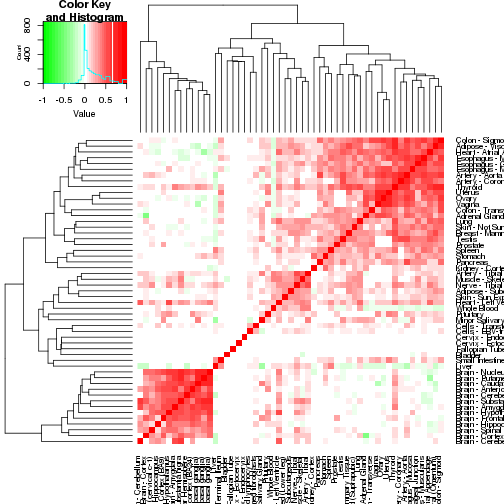

```r
col=c(rgb(seq(0,1,length=15),1,seq(0,1,length=15)),rgb(1,seq(1,0,length=15),seq(1,0,length=15)))
heatmap.2(diag(1,53)+ash_cor_full_mat[,,1],scale="none",trace="none",labRow=U,
          labCol=U,breaks=c(seq(-1,0,0.07),seq(0,0.5,0.05),seq(0.6,1,0.1)),col=col,
          distfun=function(x) dist(x,method="euclidean"),
          hclustfun=function(x) hclust(x,method="average"));
```

### gene 10

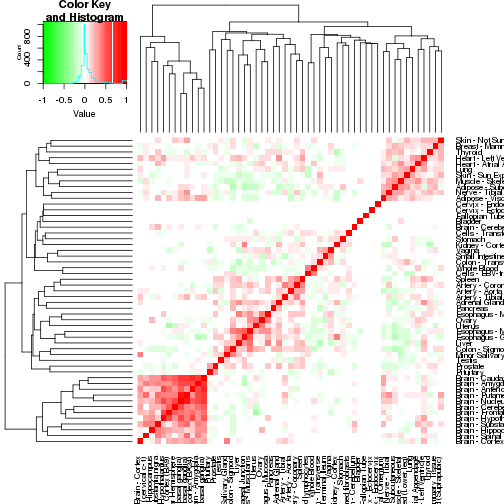

```r
heatmap.2(diag(1,53)+ash_cor_full_mat[,,10],scale="none",trace="none",labRow=U,
          labCol=U,breaks=c(seq(-1,0,0.07),seq(0,0.5,0.05),seq(0.6,1,0.1)),col=col,
          distfun=function(x) dist(x,method="euclidean"),
          hclustfun=function(x) hclust(x,method="average"));
```

### gene 500

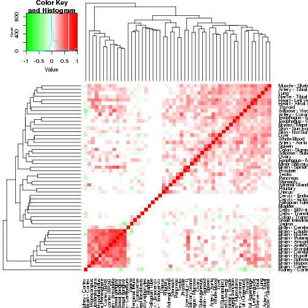

```r
library(gplots)
heatmap.2(diag(1,53)+ash_cor_full_mat[,,500],scale="none",trace="none",labRow=U,
          labCol=U,breaks=c(seq(-1,0,0.07),seq(0,0.5,0.05),seq(0.6,1,0.1)),col=col,
          distfun=function(x) dist(x,method="euclidean"),
          hclustfun=function(x) hclust(x,method="average"));
```

### gene 5000

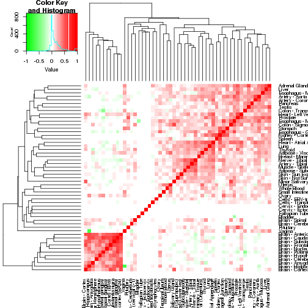

```r
heatmap.2(diag(1,53)+ash_cor_full_mat[,,5000],scale="none",trace="none",labRow=U,
          labCol=U,breaks=c(seq(-1,0,0.07),seq(0,0.5,0.05),seq(0.6,1,0.1)),col=col,
          distfun=function(x) dist(x,method="euclidean"),
          hclustfun=function(x) hclust(x,method="average"));
```

### gene 2000

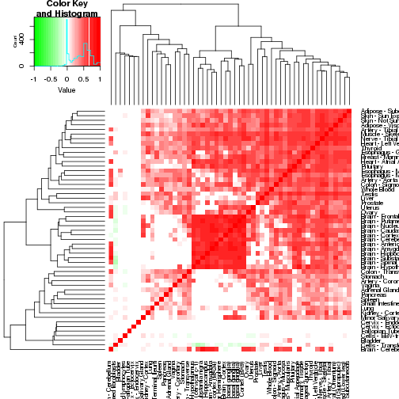

```r
heatmap.2(diag(1,53)+ash_cor_full_mat[,,2000],scale="none",trace="none",labRow=U,
          labCol=U,breaks=c(seq(-1,0,0.07),seq(0,0.5,0.05),seq(0.6,1,0.1)),col=col,
          distfun=function(x) dist(x,method="euclidean"),
          hclustfun=function(x) hclust(x,method="average"));
```

### gene 3500

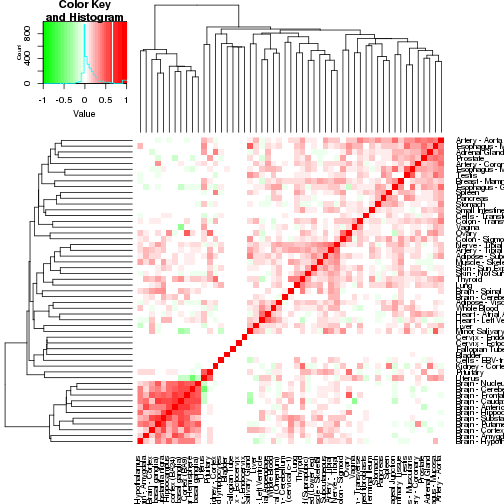

```r
heatmap.2(diag(1,53)+ash_cor_full_mat[,,3500],scale="none",trace="none",labRow=U,
          labCol=U,breaks=c(seq(-1,0,0.07),seq(0,0.5,0.05),seq(0.6,1,0.1)),col=col,
          distfun=function(x) dist(x,method="euclidean"),
          hclustfun=function(x) hclust(x,method="average"));
```